# td1 – MA1AY010 Probabilités

**NoteTD I : Révisions de Licence**

- 8 Septembre 2025-12 Septembre 2025
- Master I Isifar
- **Probabilités**

# Variables aléatoires réelles

Pour $X$ une variable aléatoire réelle et $t \in \mathbb{R}$ on note

$$F_X(t) := \mathbb{P}(X \le t)$$

la *fonction de répartition* de (la loi de) $X$ et

$$\Phi_X(t) = \mathbb{E}[\exp(itX)]$$

la *fonction caractérique* de (la loi) de $X$

## Fonctions de répartition

**Exercice 1 (Transformation affine)**

Soit $X$ une variable aléatoire réelle, $F_X$ sa fonction de répartition, $a, b$ deux réels fixés, et $Y := aX+b$

1. On suppose dans cette question que $a=1$. Comment déduire $F_Y$ de $F_X$?

   Si (la loi de) $X$ admet une densité, en est-il de même de $Y$? Si oui, exprimer dans ce cas $f_Y$ à l’aide de $f_X$.
2. On suppose dans cette question que $b=0$ et $a>0$. Comment déduire $F_Y$ de $F_X$?

   Si (la loi de ) $X$ admet une densité, à quelle condition sur $a$ en est-il de même de (la loi de) $Y$? Exprimer dans ce cas $f_Y$ à l’aide de $f_X$.
3. Répondre aux mêmes questions lorsque $b=0$ et $a=-1$?
4. Répondre enfin aux mêmes questions lorsque $a$ et $b$ sont quelconques.

**Exercice 2 (Minimum, maximum de variables indépendantes)**

Soient $X_i, i \ge 1$, des variables indépendantes. Pour $k \ge 2$, on note $Y_k = \min (X_1,...,X_k)$, $Z_k = \max(X_1,...,X_k).$

1. Dans cette question on s’intéresse à $k=2$.

   Comment déduire $F_{Y_2}$ de $F_{X_1}, F_{X_2}$? Même question pour $F_{Z_2}$.
2. Généraliser à $k$ quelconque.
3. Quelle est la loi de $Z_k$ lorsque les $\{X_i, i \ge 1\}$ sont i.i.d., $\sim \mathrm{Unif}[0,1]$?
4. Quelle est la loi de $Y_k$ lorsque les $\{X_i, i \ge 1\}$ sont des variables *exponentielles* indépendantes, avec $X_i \sim \text{Exp}(\lambda_i)$ (où pour tout $i$, $\lambda_i >0$)?

**Exercice 3**

On suppose que $X \sim \mathcal{N}(0,1)$. Que valent

$$\mathbb{P}(X \le 1), \quad \mathbb{P}(-1.23 \le X \le 0.43), \quad \mathbb{P}(X>0.32)?$$

**Exercice 4**

On suppose que l’écart à la taille moyenne $T=15.5$ des individus d’une population suit une loi normale centrée réduite.

Dans quel intervalle centré en $T$ se situent les tailles de $99\%$ des individus de la population?

**Exercice 5**

Etant donnée X une variable aléatoire gaussienne de paramètres $\mu$ et $\sigma^2$, donner la probabilité que $|X - \mu|$ dépasse $k\sigma$ pour $k = 1, 2, 3$.

*Suggestion*: On commencera par montrer que $\sigma^{-1}(X-\mu)$ suit une loi normale centrée réduite.

Reprendre les questions de l’exercice précédent lorsque $\mu=2, \sigma=2$.

Reprendre les questions de l’exercice précédent lorsque $\mu=0, \sigma=1/2$.

## Densités

**Exercice 6**

Dans les cas suivants, trouver la valeur de $C$ pour que $f$ soit une densité de probabilité.

1. $f(x) = C \frac{1}{\sqrt{x (1-x)}}, 0 <x <1,$
2. $f(x) = C \exp(-x-\exp(-x)), x \in \mathbb{R},$
3. $f(x) = C \frac{1}{1+x^2}$.

**Exercice 7**

(Mélange)

On suppose que $X$ et $Y$ sont deux variables de densités respectives $f_X, f_Y$, et que $\alpha \in [0,1]$. Montrer que $g : = \alpha f_X + (1-\alpha) f_Y$ est également une densité de probabilité.

Trouver une variable aléatoire dont $g$ est la densité.

**Exercice 8**

Soit $X$ de densité $f$, et $(\alpha, \beta) \in \overline{\mathbb{R}}^2$ sont supposés tels que
$$\mathbb{P}(\alpha < X < \beta) =1$$
On suppose que $g$ est un $C^{1}$-difféomorphisme croissant de $(\alpha, \beta)$ sur $(g(\alpha),g(\beta))$.

1. Montrer que $g(X)$ a pour densité $\frac{f(g^{-1}(x))}{g'(g^{-1}(x))} \mathbf{1}_{\{x \in (g(\alpha), g(\beta))\}}$.
2. Quelle est la densité de la variable $aX+b$, où $a>0$ et $b\in \mathbb{R}$ sont fixés?
3. Soit $Y \sim \mathcal{N}(0,1)$. Quelle est la densité de $Z = \exp(Y)$?

## Lois usuelles, calculs de loi

**Exercice 9**

(Fonctions de répartition et fonctions caractéristiques de lois usuelles)

Attention : dans le cas d’une variable continue, quand on calcule $\Phi_X$ on %doit intégrer sur $\mathbb{R}$ une fonction complexe. Trois méthodes sont envisageables.

Parfois on peut intégrer séparément partie réelle et partie imaginaire.

Parfois il est utile de se servir de la formule de Cauchy. En particulier, cette formule assure que si $f$ est une fonction *holomorphe*, si $\mathcal{C}$ est un contour fermé “raisonnable” (en particulier tout cercle ou polygone régulier), et enfin si $\overset{\circ}{\mathcal{C}}$ désigne l’ensemble des points se trouvant à l’intérieur de ce contour, alors
$$\forall a \in \overset{\circ}{\mathcal{C}}, \quad f(a) = \frac{1}{2\pi i} \oint_{\mathcal{C}} \frac{f(z)}{z-a} \mathrm{d}z.$$

Attention : cette formule montre bien que l’on ne peut pas traiter l’intégrale d’une fonction complexe en faisant “comme si” $i$ était réél (!) La *méthode des résidus* est en outre une conséquence directe de la formule de Cauchy.

Enfin, on peut utiliser le prolongement analytique (voir l’exemple de la fonction $\Gamma$).

1. Exprimer le plus simplement $F_X$ dans les cas suivants (on pourra se contenter de tracer l’allure du graphe de la fonction de répartition lorsque celle-ci ne possède pas d’expression simple).
   1. $n \in \mathbb{N}^*, p \in [0,1], X \sim \text{Bin}(n,p)$,
   2. $\lambda>0, X \sim \text{Poisson}(\lambda)$,
   3. $a>0, X\sim \text{Unif}[-a,a]$,
   4. $\lambda>0, X \sim \mathbf{exp}(\lambda)$,
   5. $\lambda>0, s \in \mathbb{N}^*$, $X \sim \Gamma(\lambda, s)$ (on rappelle que la densité $f_X$ de $X \sim \Gamma(\lambda,s)$ est telle que $f_X(x) =\frac{1}{\Gamma(s)} \lambda^s x^{s-1}\exp(-\lambda x) \mathbf{1}_{[0,\infty[}(x), x \in \mathbb{R}$),
   6. $X \sim \mathcal{N}(0,1)$,
   7. $\mu \in \mathbb{R}, \sigma>0, X \sim \mathcal{N}(\mu,\sigma^2)$.
   8. $a>0, X \sim \mathrm{Cauchy}(a)$ (on rappelle que la densité $f_X$ de la loi de Cauchy de paramètre $a$ est telle que $f_X(x) = \frac{a}{\pi(x^2+a^2)}, x\in \mathbb{R}$).
   9. (*) $X \sim \mathrm{stable}(1/2)$ (cette loi a pour densité $\sqrt{2\pi x^{-3}} \exp(-1/2x)\mathbf{1}_{[0,\infty[}(x).$)
2. Lesquelles parmi ces variables possèdent une densité?
3. Exprimer le plus simplement $\Phi_X$ pour les $7$ premières variables de la première question ci-dessus. En déduire, ou trouver par un calcul direct, $E[X],$ et $\mathrm{Var}[X]$.

**Exercice 10**

Pour des valeurs de $t$ que l’on précisera, calculer la transformée de Laplace $L(t) := \mathbb{E}[\exp(-t X)]$ et la fonction génératrice des moments $G(u) := \mathbb{E}[u^X]$ de la variable $X$ dans les cas suivants.

1. $X \sim \mathrm{Ber}(p)$, où $p \in [0,1]$,
2. $X \sim \mathrm{Bin}(n,p)$, où $n \in \mathbb{N}^*, p \in [0,1]$,
3. $X \sim \mathrm{Geom}(p)$, où $p \in [0,1]$,
4. $X \sim \mathrm{Poisson}(\lambda)$, où $\lambda>0$,
5. $X=Y_1+...+Y_n$, où les $Y_i, 1 \le i \le n$ sont des variables indépendantes, et $Y_i \sim \mathrm{Poisson}(\lambda_i)$, avec $\lambda_i >0$.

**Exercice 11**

Soit $X$ une v.a.r. de densité $f$. Quelle est la densité de $X^2$? Qu’obtient-on dans le cas où $X \sim \mathcal{N}(0,1)$?

**Exercice 12**

Soit $X \sim \exp(1)$. Calculer la densité des variables suivantes :

1. $Y = aX+b$, où $a>0$ et $b \in \mathbb{R}$. Qu’observe-t-on dans le cas où $b=0$?
2. $Z = X^2$.
3. $U = \exp(-X)$.

**Exercice 13**

Trouver la loi de $\arcsin(X)$ lorsque

1. $X \sim \mathrm{Unif}[0,1]$,
2. $X \sim \mathrm{Unif}[-1,1]$.

**Exercice 14**

On souhaite peindre un mur (infini!) en utilisant un arroseur automatique qui effectue des demi-révolutions successives. Pour simplifier le modèle, on représentera le mur par une droite verticale $\Delta$, et l’arroseur par une source ponctuelle $O$ située à $1$ mètre du mur, et émettant en tout instant $t$ de façon parfaitement rectiligne dans la direction $\overset{\rightarrow}{u}(t)$. On note $M$ la projection orthogonale de $O$ sur $\Delta$ et $\theta(t)$ l’angle entre $O \overset{\rightarrow}{u}(t)$ et $\overset{\rightarrow}{OM}$. L’intersection de $O\overset{\rightarrow}{u}$ avec $\Delta$ est notée $H(\theta)$.

On suppose en outre que lors d’une demi-révolution, $\theta(t)$ parcourt exactement l’intervalle $(-\pi/2,\pi/2)$.

On fait l’hypothèse que la demi-révolution s’effectue à vitesse angulaire constante, et on se demande quelle sera la répartition de l’épaisseur de la couche de peinture le long de $\Delta$ après un nombre entier de demi-révolutions.

1. Justifier qu’une particule de peinture choisie uniformément au hasard parmi toutes les particules est envoyée suivant un angle $\theta \sim \mathrm{Unif}(-\pi/2,\pi/2)$. Une telle particule se pose alors en $H(\theta)$, On note $h(\theta)$ l’ordonnée de $H(\theta)$ (c’est également la distance algébrique entre $O$ et $H$).
2. Exprimer $h(\theta)$ en fonction de $\theta$. Quelle est la loi de $h(\theta)$? Que pouvez-vous en déduire sur la distribution de l’épaisseur de la couche de peinture le long du mur?
3. A posteriori, quelle critique peut-on formuler sur le modèle?

**Exercice 15**

Soit $X \sim \mathrm{Cauchy}$ (de paramètre $1$).

Quelle est la loi de

1. $Y:=\frac{1}{X}$?
2. $Z:= \frac{1}{1+X^2}$?

**Exercice 16**

Soit $Z \sim \mathcal{N}(0,1)$. Montrer que pour tout $x>0$,

$$\left(x^{-1}-x^{-3}\right) \exp(-x^2/2) \le \sqrt{2\pi} \mathbb{P}(Z>x) \le x^{-1} \exp(-x^2/2).$$

*Indication* : on pourra penser à utiliser le changement de variable $y=x+z$ pour obtenir l’inégalité de droite, et on commencera par calculer la dérivée de $\left(x^{-1}-x^{-3}\right) \exp(-x^2/2)$ pour obtenir celle de gauche.

**Exercice 17 (Calcul d’une loi conditionnelle discrète)**

Soient $X_1,...,X_n$ des variables de Poisson, indépendantes, de paramètres respectifs $\lambda_1,...,\lambda_n$.

1. Déterminer la loi de $Y:=\sum_{k=1}^n X_k$.
2. Pour $r \in \mathbb{N}$, que vaut la loi conditionnelle de $(X_1,...,X_n)$ sachant $Y=r$?

# Lois jointes

## Exemples divers

**Exercice 18**

On suppose que le nombre $X$ d’oeufs pondus par un insecte suit une loi de Poisson de paramètre $\lambda>0$ et que la probabilité qu’un oeuf meure sans éclore est, indépendamment des autres oeufs, égale à $1-p$, où $p \in ]0,1[$.

1. Démontrer que le nombre $Y$ d’oeufs qui arrivent à éclosion suit une loi de Poisson de paramètre $\lambda p$.
2. Quelle est la loi jointe de $(Y,Z)$, où $Z= X-Y$ est le nombre d’oeufs morts avant éclosion?

**Exercice 19**

(Somme d’exponentielles et $\chi^2$)

Soit $\lambda>0$ et $(Y_i)_{1 \le i \le n}$ des variables i.i.d, $\sim \exp(\lambda)$.

1. Calculer $\mathbb{E}[\exp(-tY_1)]$ pour $t \ge 0$.
2. Calculer $\mathbb{E}\left[\exp(-t\sum_{i=1}^n) Y_i \right]$ pour $t \ge 0$.
3. Montrer que la densité de la variable $X= \sum_{i=1}^n Y_i$ est proportionnelle à $x^{n-1} \exp(-\lambda x) \mathbf{1}_{x \ge 0}$. En déduire la valeur de cette densité.
4. Soient $X_n, n \ge 1$ des variables i.i.d, $\sim \mathcal{N}(0,1)$. On pose $\chi^2(n):=\sum_{i=1}^n X_i^2$, $Z:=X_1X_2 +X_3X_4$. \ Calculer $\Phi_{\chi^2(n)}, \Phi_Z$. Pouvez-vous deviner la distribution de $Z$ (on pourra utiliser un résultat d’un exercice précédent)?

**Exercice 20**

Soit $Z = (X, Y )$, une variable aléatoire à valeurs dans $\mathbb{R}^2$. On suppose que $Z$ admet une densité $f$ définie par

$$f(x, y) = \frac{4}{\pi \sigma^2} \exp\left(-\frac{x^2+y^2}{\sigma^2}\right) \mathbf{1}_{\{x \ge |y|\}},$$

où $\sigma>0$.

1. Vérifier que $f$ est bien une densité de probabilité.
2. Calculer les lois de $X$ et de $Y$ . Les variables aléatoires $X$ et $Y$ sont-elles indépendantes ?
3. Calculer la loi de $(X - Y, X + Y )$ et montrer que $X - Y$ et $X + Y$ sont indépendantes.

**Exercice 21**

1. Soit $X_1,...,X_n$ des variables i.i.d, $\sim \mathcal{N}(0,1)$, et $Z=\sum_{i=1}^n \alpha_i X_i$ (où les $\alpha_i, i=1,...,n$ sont de rééls fixés). Quelle est la loi de $Z$?
2. Soit $(X_1,...,X_n) \sim \mathcal{N}(0,A)$. Quelle est la loi de $Z=\sum_{i=1}^n \alpha_i X_i$?
3. Soit $(X_1,...,X_n) \sim \mathcal{N}(0,A)$. Quelle est la loi de $(Z_1,Z_2)$, où, pour des rééls $\alpha_{i,1}, \alpha_{i,2}, i=1,...,n$ fixés,
   $$Z_1=\sum_{i=1}^n \alpha_{i,1} X_i, Z_2=\sum_{i=1}^n \alpha_{i,2} X_i.$$
4. Généraliser la question précédente en exprimant la loi de
   $$(Z_1,...,Z_n) = (X_1,...,X_n) P,$$
   où $P$ est une matrice $n \times n$.
5. Soient $X,Y$ deux variables indépendantes, $\sim \mathrm{Unif}[0,1]$. Quelle est la loi de $S=X+Y$?
6. Soient $X, Y$ des variables indépendantes de loi respectives $\Gamma(a,c), \Gamma(b,c)$, où $a,b,c>0$. On pose $S=X+Y, T= \frac{X}{X+Y}$ Quelle est la loi du couple $(S,T)$?
7. Soient $X,Y$ deux variables indépendantes, $\sim \mathrm{Unif}[0,1]$. On pose $U = \sqrt{-2\log(X)} \cdot \cos(2\pi Y), V = \sqrt{-2\log(X)} \cdot \sin(2\pi Y)$. Quelle est la loi du couple $(X,Y)$?
8. Soient $X,Y$ deux variables indépendantes, $\sim \mathcal{N}(0,1)$. On pose $T = \frac{Y}{X}$. Quelle est la loi de $T$?
9. Soient $(X,Y)$ un couple de variables indépendantes, $\sim \mathcal{N}(0,1)$. On pose $U=X, V= X^2 + Y^2$. Quelle est la loi de $(U,V)$?
10. Soit $X$ de densité $\exp(-x) \mathbf{1}_{\mathbb{R}_+}(x)$. On pose $U = [X]$ et $V= X-[X]$, la partie entière, resp. la partie décimale de $X$. Quelle est la loi de $(U,V)$?

**Exercice 22**

Soient $X_1, X_2$ deux variables indépendantes et identiquement distribuées suivant la loi $\mathrm{Unif}\{1,2,3\}$.

On note $U = \min\{X_1,X_2\}$, $V= \max\{X_1,X_2\}$ et enfin $S= U+V$.

1. Déterminer la loi jointe de $(U, V)$ et $(V, S)$.
2. En déduire les lois de $U, V$, et $S$. Calculer les lois de $UV$ et $VS$.
3. Calculer les covariances et les coefficients de corrélation de $(U, V)$ et $(V, S)$.

## Le cadre gaussien

**Exercice 23**

On considère deux variables indépendantes $Y \sim \mathcal{N}(0,1)$ et
$$\varepsilon= \begin{cases} & 1 \mbox{ avec probabilité } p \\ & -1 \mbox{ avec probabilité } 1-p, \end{cases}$$

où $p \in (0,1)$.

1. Quelle est la loi de $Z= \varepsilon Y$
2. Quelle est la loi de $Y+Z$?
3. Le vecteur $(Y,Z)$ est-il un vecteur gaussien?

**Exercice 24**

Soit $(X,Y,Z)$ le vecteur aléatoire gaussien d’espérance $(1,1,0)$ et de matrice de covariance

$$K = \begin{pmatrix} 2 & 1 & 1 \\ 1 & 2 & 2 \\ 1 & 2 & 2 \end{pmatrix}.$$

1. Ecrire la fonction caractéristique de $(X,Y,Z)$.
2. Trouver la loi de $2X+Y+Z$, de $4X-2Y+Z$, enfin de $Y-Z$.
3. Le vecteur $(X,Y)$ admet-il une densité dans $\mathbb{R}^2$. Si oui, laquelle?
4. Pour $a \in \mathbb{R}$ on définit $u_a : \mathbb{R}^3 \to \mathbb{R}^3$ de matrice

   $$A = \begin{pmatrix} 1/\sqrt{2} & 0 & 0 \\ a & -2a & 0 \\ 0 & 1 & -1\end{pmatrix}.$$

   Déterminer la loi de $u_a(X-1,Y-1,Z)$ en fonction de $a$.

   Pour quelle valeur de $a$ les deux premières coordonnées de $u_a(X-1,Y-1,Z)$ suivent-ils une loi normale centrée réduite sur $\mathbb{R}^2$?

**Exercice 25**

Soit $\rho\in ]-1,1[$ et $(X,Y)$ un vecteur gaussien centré de matrice de covariances $M = \begin{pmatrix} 1 & \rho \\ \rho & 1 \end{pmatrix}$. On notera $\sigma = \sqrt{1-\rho^2}$.

1. Calculer det($M$), $M^{-1}$, puis exprimer la densité $f_{(X,Y)}$ du vecteur $(X,Y)$.
2. Montrer que

   $$g_x(y) := \frac{f_{(X,Y)}(x,y)}{f_X(x)} = \frac{1}{\sigma \sqrt{2\pi}} \exp \left( - \frac{1}{2(1-\rho^2)} \left(y-\rho x\right)^2\right).$$

   Montrer que pour tout $x \in \mathbb{R}$, $y \to g_x(y)$ définit une densité.
3. Si on note $Y_x$ une variable de densité $g_x$, que pouvez-vous dire sur la loi de $Y_x$?
4. Trouver $\alpha$, $\beta$ deux réels tels que $(X, \alpha X + \beta Y)$ suit la loi normale centrée réduite.

Remarquer que l’on peut écrire $Y= -\frac{\alpha}{\beta} X +\frac{1}{\beta}(\alpha X + \beta Y)$. Sauriez-vous dire pourquoi cette écriture est intéressante?

**Exercice 26**

Montrer que le vecteur aléatoire de dimension $3$ de moyenne $m = (7,0,1)$ et de matrice de covariances

$$K = \begin{pmatrix} 10 & -1 & 4 \\ -1 & 1 & -1 \\ 4 & -1 & 2 \end{pmatrix}$$

appartient presque sûrement à un hyperplan affine de $\mathbb{R}^3$ que l’on déterminera.

# Notions de théorie de la mesure

**Exercice 27**

1. Soient $E$ et $F$ deux espaces, $f$ une application de $E$ dans $F$ et $\mathcal{F}$ une tribu sur $F$. Montrer que $\mathcal{E}_f:=\{f^{-1}(A), A \in \mathcal{F}\}$ est une tribu sur $E$. La fonction $f : (E, \mathcal{E}_f) \to (F,\mathcal{F})$ est-elle mesurable?
2. Supposons $E= \mathbb{R}$, $(F, \mathcal{F})= (\mathbb{R}, \mathcal{B}(\mathbb{R}))$ et $f: x \to x^2$.
   - Montrer que $\mathcal{E}_f := \big\{A \in \mathcal{B}(\mathbb{R}), A = -A \big\}$.
   - (*) Déterminer l’ensemble des fonctions mesurables de $(\mathbb{R}, \mathcal{E}_f)$ dans $(\mathbb{R},\mathcal{B}(\mathbb{R}))$.

**Exercice 28**

Dans cet exercice, $\mu$ est une mesure sur $(\mathbb{R},\mathcal{B}(\mathbb{R}))$ qui vérifie les conditions suivantes :

**C1**

$\forall x \in R, \ \mu(\{x\}) = 0$.

**C2**

Pour tous réels $a < b : \mu([a, b]) < +\infty$.

1. La mesure de Lebesgue $\lambda$ sur $\mathbb{R}$ vérifie-t-elle ces conditions? Et la mesure de Dirac $\delta_0$? Quid de la loi d’une variable de Poisson de paramètre $a \ge 0$? et de la loi d’une variable uniforme sur $[0,1]$?
2. Calculer $\lim_{n \to \infty} \mu\left( \big]-\frac{1}{n}, \frac{1}{n}\big[ \right)$.
3. Calculer $\mu(\mathbb{Q})$.
4. Soit $A \in \mathcal{B}(\mathbb{R})$. On définit la fonction $f_A$ comme suit :

   $$f_A : \begin{cases} & \mathbb{R} \to [0,+\infty[ \\ & x \mapsto f_A(x) = \mu(A \cap [-|x|,|x|])\end{cases}$$

   Pourquoi la fonction $f_A$ est-elle bien définie ? Calculer $f_A(x)$ pour $A = \mathbb{Q}$.
5. On suppose dans cette question que $\mu = \lambda$. Représenter graphiquement l’allure de $f_A$ pour $A = \mathbb{R}$.
6. Même question pour $A = [0, 1]$.

**Exercice 29**

(Mesure image)

**Situation générale. Premiers exemples.**

Soient $(F,\mathcal{F})$ et $(G,\mathcal{G})$ des espaces mesurables, $\phi : F \to G$ une fonction mesurable. Soit $\mu$ une mesure sur $(F, \mathcal{F})$. On définit $\nu : \mathcal{G} \to [0,+\infty]$ par $\nu(A) = \mu(\phi^{-1}(A))$.

1. Montrer que $\nu$ est une mesure sur $(G,\mathcal{G})$. On dit que c’est la mesure image de $\mu$ par $\phi$, et on la note également $\phi \circ \mu$.
2. On choisit $\mu = \delta_{a}$, où $a \in F$, et on suppose dans cette question que les singletons sont des éléments de $\mathcal{G}$. Déterminer $\phi \circ \delta_a$.
3. On suppose que $\mu$ est une mesure de probabilité sur $(F, \mathcal{F})$ (i.e. $\mu$ est une mesure vérifiant $\mu(F)=1$). On fixe $B \in \mathcal{F}$ et on choisit $(G,\mathcal{G}) = (\mathbb{R},\mathcal{B}(\mathbb{R}))$. Déterminer $(\mathbf{1}_{B})\circ \mu$.

Variable aléatoire. Image d’une variable aléatoire: Il est important de noter que la définition de “loi” d’une variable aléatoire réelle est étroitement liée à la notion de mesure image. Par exemple, supposons $(\Omega, \mathcal{F}, \mathbb{P})$ est un espace probabilisé, et que $X : \Omega \to \mathbb{R}$ est une variable aléatoire réelle (c’est-à-dire que $X$ définit une application mesurable de $(\Omega, \mathcal{F})$ vers $(\mathbb{R}, \mathcal{B}(\mathbb{R}))$). Alors la loi de $X$, notée $P_X$, n’est autre que la mesure image $X \circ \mathbb{P}$, qui est une mesure de probabilité sur $(\mathbb{R}, \mathcal{B}(\mathbb{R}))$.

Supposons maintenant que $X$ est une variable aléatoire réelle de loi $P_X$, et que $f : \mathbb{R} \to \mathbb{R}$ est borélienne. Quelle est la loi $P_Y$ de la variable aléatoire $Y=f(X)$?

# Convergence(s)

**Exercice 30**

(LFGN et TCL)

1. Pour $n \in \mathbb{N}$, exprimer $\Phi_{S_n/n}$ en fonction de $n, x_0, \Phi_{X}$. La suite de fonctions $(\Phi_{S_n/n})_{n \in \mathbb{N}}$ possède-t-elle une limite simple?
2. On suppose ici que $X$ est tel que $E[X]=0$, $E[X^2]=\sigma^2<\infty$. Pour $n \in \mathbb{N}$, exprimer $\Phi_{\frac{S_n}{\sqrt{n}}}$ en fonction de $n, x_0, \Phi_{X}$. La suite $(\Phi_{\frac{S_n}{\sqrt{n}}})_{n \in \mathbb{N}}$ possède-t-elle une limite simple?

**Exercice 31**

On joue à un jeu équilibré, on remporte un euro à chaque main gagnée, et on perd un euro à chaque main perdue. On note $G_n$ le gain algébrique lorsque $n$ mains ont été jouées.

1. Soit $\alpha >0, A>0$ fixés. En utilisant l’inégalité de Bienaymé-Chebychev, trouver un majorant de la quantité $\mathbb{P}(G_n \ge A n^{\alpha}).$ Interpréter le résultat.
2. Discuter l’ordre de grandeur, lorsque $n \to \infty$, de la borne obtenue en fonction de $A$ et $\alpha$. Peut-on être plus précis sur l’ordre de grandeur de $\mathbb{P}(G_n \ge A n^{\alpha})$ lorsque $\alpha \le 1/2$? Qu’obtient-on en particulier lorsque $\alpha=1/2$?

**Exercice 32**

(Convergence en loi d’une variable uniforme)

1. Soit, pour $n \ge 1$, $X_n \sim \mathrm{Unif}(\{1,...,n\})$ (i.e $\forall i \in \{1,..,n\},\ P(X_n =i)=1/n$). Montrer que la suite $n^{-1}X_n$ possède une limite en loi, que l’on déterminera.
2. On considère maintenant $X_n \sim \mathrm{Unif}\left( \left\{\frac{1}{2^n}, \frac{2}{2^n},...,\frac{2^n}{2^n}\right\} \right).$ Montrer que $X_n$ possède une limite en loi. Voyez-vous le lien avec la définition de l’intégrale de Riemann?

**Exercice 33**

Géométrique et exponentielle

1. Soit $\lambda >0$ et $X \sim \exp(\lambda)$. Montrer que $\lceil X \rceil$ suit une loi géométrique dont on déterminera le paramètre en fonction de $\lambda$.
2. Le but de cette deuxième partie est de montrer comment on peut “construire” une variable exponentielle à partir d’une variable géométrique. Dans la suite $\lambda>0$ est fixé.
3. On rappelle qu’une variable géométrique de paramètre $p$ représente l’indice de premier succès d’une suite d’essais i.i.d, $\sim\mathrm{Ber}(p)$. \ Pour $\delta>0$ on considère $Y_{\delta} \sim \mathrm{Geom}(p_{\delta})$ où $p_{\delta}:= \delta\lambda$.  
   Calculer $P(Y_{\delta} > m)$ en fonction de $m, \delta$.
4. On suppose que les tentatives suivant une loi de Bernoulli ont lieu aux temps $\delta, 2\delta, 3\delta, \ldots$. Montrer que la probabilité qu’aucun succès n’ait été observé jusqu’au temps $t$ converge vers $e^{-\lambda t}$ lorsque $\delta \to 0$ (On remarquera que lorsque $\delta$ est très petit, au temps $t$, environ $t/\delta$ tentatives ont eu lieu). Ainsi, le temps de premier succès est approximativement une variable exponentielle de paramètre $\lambda$.

**Exercice 34**

*Approximation de la loi binômiale par une loi de Poisson*

On rappelle qu’une variable $X$ qui suit la loi de Poisson de paramètre $\lambda>0$ vérifie  
$P(X=k)= \exp(-\lambda) \lambda^k/k!, k \in \mathbb{N}$

1. Que vaut $E[X], \mathrm{Var}[X]$?
2. Soit $Y_n \sim \mathrm{Bin}(n,p_n)$, avec $np_n \to \lambda >0$. Montrer que, pour $k \in \mathbb{N}$ fixé, $P(Y_n=k) \to P(X=k)$ lorsque $n \to \infty$, $np_n \to \lambda$.
3. Application : Un avion transporte 416 passagers. La compagnie aérienne qui l’affrète a remarqué qu’en moyenne, un passager qui réserve sa place ne se présente pas à l’enregistrement avec probabilité $0.01$, et pour simplifier on suppose que les événements de présence des passagers sont mutuellement indépendants. Afin d’anticiper les absences, la compagnie vend $420$ réservations pour chacun des vols de l’avion. Sur quelle proportion de vols la compagnie sera-t-elle forcée de refuser des clients (on utilisera une approximation poissonienne de la loi binômiale)?
4. Même question, mais on utilisera cette fois le théorème de la limite centrale pour évaluer la proportion.

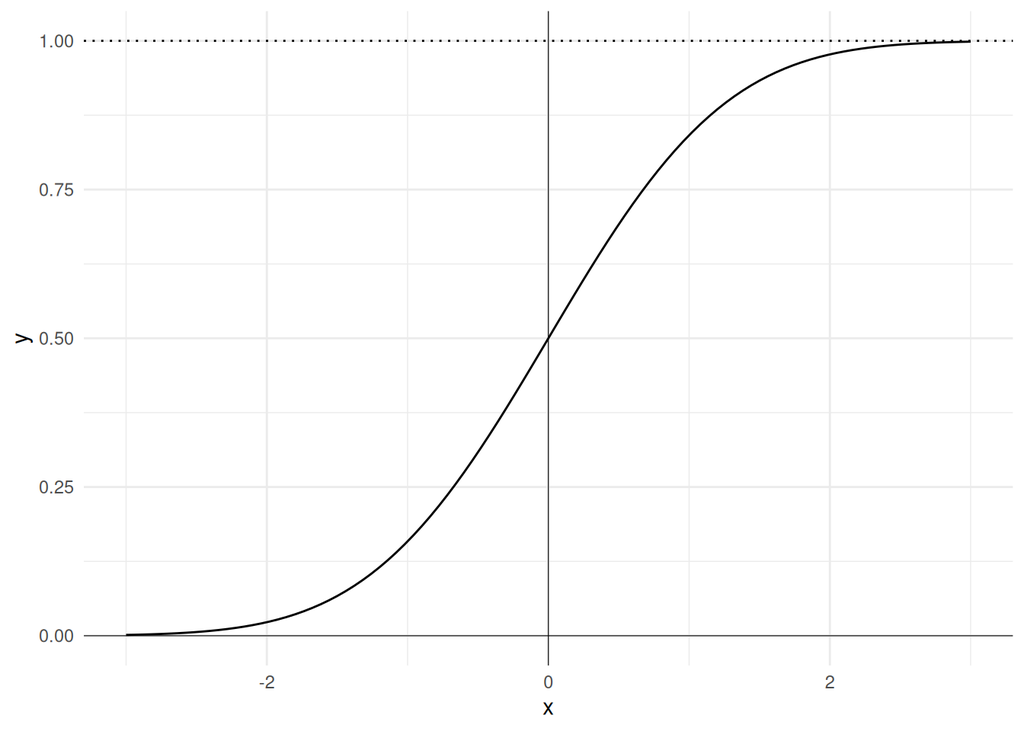

Intégrale $\Pi(t)$ de la Loi Normale Centrée Réduite $\mathcal{N}(0;\,1)$